Tholonia - 620-M-Laws-for-All  
The Existential Mechanics of Awareness  
Duncan Stroud  
Published: January 15, 2020  
Updated: Updated: Jan 1, 2026  
Welkin Wall Publishing  
ISBN-10:  
ISBN-13: 978-1-6780-2532-8  
Copyright ©2020 Duncan Stroud CC BY-NC-SA 4.0

# Appendix I: The 236 Pattern for Various Systems Data

The tholonic model posits that the pattern of 2, 3, and 6 (with 18 as the product) represents a fundamental structure that appears across diverse systems. This appendix demonstrates how the N-D-C (Negotiation-Definition-Contribution) pattern, represented by the tholonic trigram, maps onto various physical laws, mathematical constants, and conceptual frameworks.

## The Universal Pattern

The 236 pattern emerges from the tholonic structure where: - **6** represents the source state, the balanced originating point from which the two children emerge. - **2** represents Definition and Limitation, emerging from the source as the state where unity has been divided or split into duality - **3** represents Contribution or Integration, emerging from the source as the force that brings together and synthesizes - **18** represents the end child or resulting stable pattern, created from the interaction of 6’s children (2 and 3), yielding 6 × 3 or 2 × 3 × 3

This pattern appears consistently across multiple domains, suggesting a fundamental organizing principle in nature.

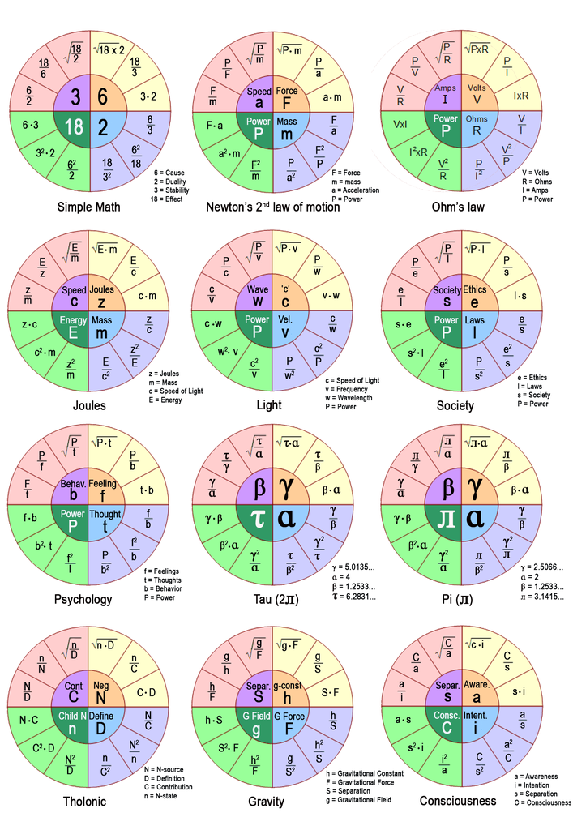

The diagram above illustrates how this pattern manifests in 12 different systems:

1. **Simple Math**: The fundamental numerical relationships (2, 3, 6, 18)
2. **Newton’s 2nd Law**: Force, Mass, and Power arranged in the tholonic structure
3. **Ohm’s Law**: Voltage, Current, Resistance, and Power relationships
4. **Energy (Joules)**: Speed, Mass, and Energy in E = mc²
5. **Light**: Wave properties (speed, frequency, wavelength) and Power
6. **Society**: Ethics, Laws, and Power in social systems
7. **Psychology**: Feelings, Thoughts, Behavior, and Power
8. **Tau (2π)**: Mathematical constant relationships
9. **Pi (π)**: The fundamental circle constant
10. **Tholonic**: The base N-D-C pattern
11. **Gravity**: Gravitational constant, Force, Field, and Separation
12. **Consciousness**: Awareness, Intention, Separation, and Consciousness

Each circular diagram shows how the fundamental triad generates related concepts in the outer segments, with the pattern maintaining consistent mathematical relationships.

## The Electromagnetic Spectrum and the 236 Pattern

The profound connection between electricity and light becomes undeniable when we examine the electromagnetic spectrum through the lens of Ohm’s Law. The mathematical structure is identical:

**Ohm’s Law:**  
Voltage = Current × Resistance  
V = I × R

**Light:**  
Speed of light = Wavelength × Frequency  
c = λ × f

This structural identity reveals that these are not merely analogous but represent the same underlying electromagnetic phenomenon expressed in different contexts.

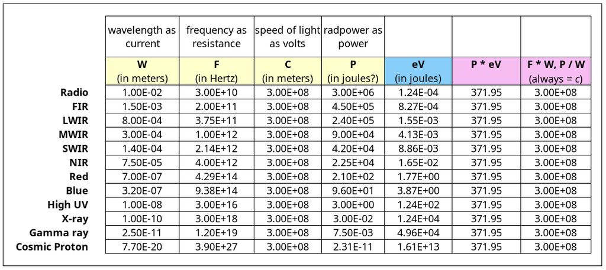

The table above demonstrates this equivalence explicitly by mapping electrical properties onto light properties:

- **Voltage (V)** ↔︎ **Speed of light (c)** - both remain constant at 3.00E+08
- **Current (I)** ↔︎ **Wavelength (W)** - the variable “flow” component
- **Resistance (R)** ↔︎ **Frequency (F)** - the variable “constraint” component
- **Power (P)** ↔︎ **Radpower (P)** - the energy transfer rate in both systems

Most remarkably, the product **P × eV = 371.95** remains constant across the entire electromagnetic spectrum, from radio waves (wavelength 1.00E-02 meters) to cosmic protons (wavelength 7.70E-20 meters). This invariant relationship, spanning 18 orders of magnitude, mirrors how electrical power relationships remain constant in circuits despite variations in voltage, current, and resistance.

The consistency of this pattern reveals that electricity and light are not separate phenomena that happen to follow similar mathematical rules. They are manifestations of the same electromagnetic reality, expressing itself through different contexts. The tholonic 236 pattern underlies both, with the source (6) generating the dual aspects of wave and particle (2), integrated through propagation and interaction (3), resulting in stable observable patterns (18) that we measure as radio waves, visible light, x-rays, or electrical current.

This structural identity across physical, mathematical, and conceptual domains demonstrates that the 236 tholonic pattern represents a fundamental organizing principle that transcends specific contexts, operating at multiple scales from subatomic particles to electromagnetic radiation to social systems.

## Implications

The universality of the 236 pattern implies that: 1. Disparate systems may share deeper structural similarities than surface differences suggest 2. Mathematical relationships in physics may have analogues in social, psychological, and conceptual realms 3. The tholonic model provides a unified framework for understanding pattern recurrence across domains 4. Understanding this pattern in 1 domain may offer insights into its manifestation in others

This cross-domain applicability strengthens the tholonic thesis that reality operates according to consistent principles that manifest differently depending on context and scale.